# 文本分析训练

这个Task主要练习文本分析的基础知识,包括如何用R进行中文分词，词频统计等等。

相关的阅读资料包括：

公号输入“琅琊榜”、“人民的名义”，“欢乐颂2”，可以阅读文本分析的相关案例。

本Task用到的是琅琊榜小说文本进行一些基础的练习。

截止时间：11月11日早8点；将HTML文件命名为【姓名+TASK 3.2】提交到作业邮箱。

## 任务一：

提供了琅琊榜小说文本，将文本读入并将数据集命名为langya，展示数据集的前10行。

提示：处理中文时最常见的错误就是乱码问题，这往往是是由于编码造成的，通常可以通过设置UTF-8编码来解决

```
##  [1] "　　第一卷 江左梅郎 第一章 两姓之子"
##  [2] "　　"
##  [3] "　　琅琊阁。"
##  [4] "　　那是一个天下最神秘的地方，但同时，却也是天下最公开的地方。"
##  [5] "　　世上凡是听过琅琊阁之名的人，都知道它位于琅琊山顶，是一处美仑美焕的风雅庄园，园内亭台楼阁，秀女灵仆，园外一条宽阔的石板主路，蜿蜒而下，直通山脚的官道。天南海北、水陆两行的人都可以很轻易地到达这里，可以很随意地入它的门庭。除了食宿都要收取相应的费用以外，琅琊阁对来客几乎没有其他任何的限制。"
##  [6] "　　然而就算是这样明明白白地敞开在天下人的眼前，迄今为止也尚无一人能够弄清楚它到底是怎样的一个组织，它究竟是如何运作的。"
##  [7] "　　人们只知道，无论你想知道什么，只要带着足够的银子进到琅琊阁内，就能得到满意的答案，数十年间，没有一次倒过招牌。"
##  [8] "　　曾有人很奇怪地问过琅琊阁主：“你不可能真的什么都知道，如果有人来问皇帝陛下有几根头发，或者伏灵圣女昨晚睡觉时梦见了谁，你怎么回答？”"
##  [9] "　　琅琊阁主邪恶地一笑道：“因为所有问题都由我定价。比如刚才那两个问题，我就定价三千万两银子。谁肯付这么一大笔钱，只为了砸我的招牌玩玩？人们真正花钱要知道的事情，多半都是可以调查出来的事情，至少我目前为止，还没遇上象你这么无聊的人。”"
## [10] "　　那人撇撇嘴失望地道：“咦，你原来是个骗子。”"
```

## 任务二：

进行初步的分词尝试，加载jiebaR分词包，通过cutter来设置分词环境。

提示：本任务有三个关键点，

1、如何进行逐行分词；

2、如何添加自定义词典,jieba提供的是一个通用的词根库，因此对于琅琊榜里的一些词语比如梅长苏、琅琊阁这样的是分不出来的，如果要进行分词该怎么办呢？就要向词根库里添加这些自定义词根，即需要有一个自定义词典，大家想想哪里有这样现成的词典？搜狗细胞词库是一个特别好的东东，但是唯一的缺点就是需要把它转成txt，老师只能帮你到这了。

3、如何去掉停用词，语言中使用的功能词（语气助词、副词、介词、连接词），这些功能词通常极其普遍，并没有什么实际含义，比如：“你、我、他、了、的”，在分词的时候最好把这些停用词去掉，可以优化分词结果，很多机构都给出了自己的停用词表，如“百度”，“哈工大”，“四川大学机器自然实验室”等。我们给出了一个汇总的停用词表供大家使用。

用head展示分词结果的前几项。

```
## [[1]]
## [1] "　"       "　"       "第一卷"   "江左梅郎" "第一章"   "两姓"
## [7] "之子"
##
## [[2]]
## [1] "　" "　"
##
## [[3]]
## [1] "　"     "　"     "琅琊阁"
##
## [[4]]
## [1] "　"   "　"   "天下" "神秘" "地方" "天下" "公开" "地方"
##
## [[5]]
##  [1] "　"       "　"       "世上"     "听过"     "琅琊阁"   "之名"
##  [7] "位于"     "琅琊山顶" "一处"     "美仑"     "美焕"     "风雅"
## [13] "庄园"     "园内"     "亭台楼阁" "秀女"     "灵仆"     "园外"
## [19] "一条"     "宽阔"     "石板"     "主路"     "蜿蜒"     "直通"
## [25] "山脚"     "官道"     "天南海北" "水陆"     "两行"     "轻易"
## [31] "到达"     "随意"     "地入"     "门庭"     "食宿"     "收取"
## [37] "费用"     "琅琊阁"   "来客"
##
## [[6]]
##  [1] "　"       "　"       "明明白白" "敞开"     "天下"     "眼前"
##  [7] "迄今为止" "尚无"     "一人"     "弄清楚"   "组织"     "运作"
```

## 任务三：

进行词频统计，要求：只对字符数大于等于2的词根进行统计，将结果按照降序排列。

存成数据集命名为freq，其中第一列为词根，第二列为频数，展示str(freq)和数据集的前6项

```
## 'data.frame':    34315 obs. of  2 variables:
##  $ text: Factor w/ 34315 levels "阿牛","阿庆",..: 15607 12284 26784 6719 30727 15736 5430 28076 23399 14331 ...
##  $ Freq: int  2966 1145 937 868 862 737 676 664 629 594 ...
```

```
##         text Freq
## 15607 梅长苏 2966
## 12284   靖王 1145
## 26784 萧景睿  937
## 6719    飞流  868
## 30727   誉王  862
## 15736   蒙挚  737
```

## 任务四：

统计主要人物在全书的出场频次并绘制柱形图。

提示：这里需要注意的是对于某一个人物可能要统计他不同称谓， 例如梅长苏就有好几种叫法，比如苏哲、小殊、林殊等等说法。

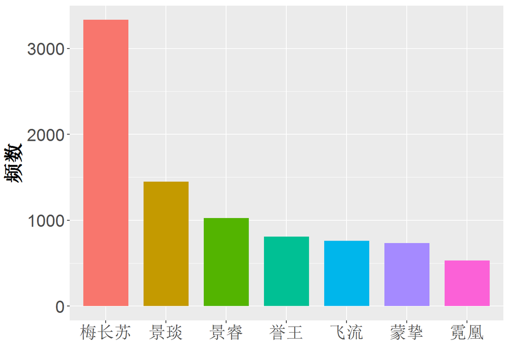

## 任务五：附加题

看到之前的报告大家的词云图做的惨不忍睹，决定来一个附加题，请自学如何利用tagxedo在线网站制作美腻的词云图！学会的同学请附上美图一张~~